# Mapping Water Customer Clusters

Dan Larson

4/24/2020

### Overview

I chose to showcase this project because it had a lot of diverse elements:collaboration with multiple stakeholders, data collection, messy data,data from multiple sources,geocoding using Google API, exploratory anaylses, machine learning (segmentation),use of an additional analysis platform (ArcGIS Pro), and mapping. The final result helped inform the “Save it for the Salmon” and the ongoing “Clackamas Watershed Resiliency Project”.

### Purpose

Segmentation, more specifically psychographic and behavioral segmentation, is common in the electrical utility sector but not water. I thought this would be a novel contribution. I was curious how water customer attitudes around water conservation and climate change manifested among customers with the intutition that there are different customer “archetypes”. Knowing about these archetypes can help focus messaging and this project was developed as the starting point for an ongoing social marketing campaign around watershed conservation and protection.

### Research Questions

1. Do water customer attitudes show attitudinal clustering around climate change, water conservation,trust, and place attitudes.
2. Do these attitudinal clusters exhibit spatial clustering within the water service area?

## 1. Load Packages

```r
library(tidyverse)  # Set of useful core packages
library(Hmisc)      # Misc utility package
library(mice)       # For imputation
library(cluster)    # Clustering algorithms
library(factoextra) # Extract and visualize the output of multivariate data analyses
library(psych)      # General purpose toolbox for personality, psychometric theory and experimental psychology
library(NbClust)    # Provides 30 indexes for determining the optimal number of clusters in a data set
library(clValid)    # Statistical and biological validation of clustering results
library(fpc)        # Flexible procedures for clustering - Various methods for clustering and cluster validation
library(DataExplorer) # Easy exploratory data analysis
library(corrplot)   # Makes pretty correlation plots
```

## 2. Exploratory Data Analysis (EDA)

Load Data

```r
load(file = "watercust_masterdata.rda")

watercust<-watercust_masterdata
```

Inspect Data

```r
#Initially inspect data
glimpse(watercust)
```

```
## Observations: 381
## Variables: 17
## $ ResponseID           <fct> R_1LZii49jY6D461r, R_1irfCfBpf9IYcB4, R_3qrLt0VH…
## $ ID                   <dbl> 1099, 1095, 1175, 1047, 1133, 1003, 1036, 1019, …
## $ Age1                 <dbl> 74, NA, 72, 69, 68, 72, 43, 43, 72, 38, NA, NA, …
## $ Education1           <dbl> 3, 4, 2, 3, 1, 2, 2, 2, 3, 3, NA, NA, 4, 4, 4, 4…
## $ Income1              <dbl> 1, 1, 1, 1, 1, 0, NA, 1, NA, 2, NA, NA, 2, 0, 2,…
## $ Political.Attitudes1 <dbl> 3, 0, 0, 1, 4, 2, NA, 2, 2, 1, NA, NA, 1, 1, 3, …
## $ Income               <dbl> 3, 4, 3, 3, 4, 1, NA, 4, NA, 5, NA, NA, 6, 2, 6,…
## $ inc_val              <dbl> 62499.5, 87499.5, 62499.5, 62499.5, 87499.5, 125…
## $ PNWClimateInd        <dbl> 2.00, NA, 4.00, 4.00, NA, 2.75, 2.75, 4.00, 3.00…
## $ CCImpactInd_rc       <dbl> 1.625, NA, 2.875, 3.125, NA, 2.000, 2.625, 3.250…
## $ pro_water_con        <dbl> 1.75, NA, 2.50, 2.50, NA, 1.50, 2.75, 2.75, 2.50…
## $ Gross_WTP            <dbl> NA, NA, NA, 11, 6, NA, NA, 6, NA, 9, NA, NA, 12,…
## $ Trust                <dbl> 16, 3, 20, 17, 15, 17, 24, 23, NA, 19, NA, NA, 2…
## $ Trust_Ind            <dbl> 1.7777778, 0.3333333, 2.2222222, 1.8888889, 1.66…
## $ Place_Attitudes      <dbl> 2.0000000, 2.0000000, 1.7777778, 2.0000000, 0.44…
## $ lon                  <dbl> -122.6362, -122.6322, -122.6247, -122.6232, -122…
## $ lat                  <dbl> 45.33123, 45.32230, 45.33011, 45.32992, 45.32535…
```

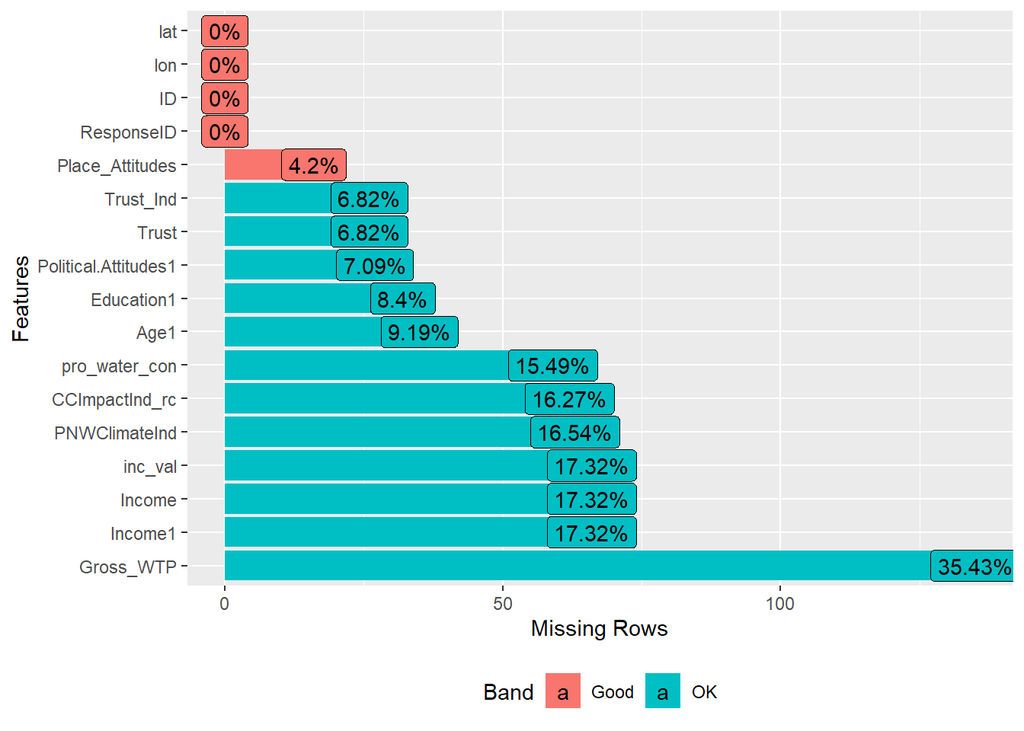

```r
# Visualize variables in dataset
plot_str(watercust)


#Explore missing values

plot_missing(watercust)
```

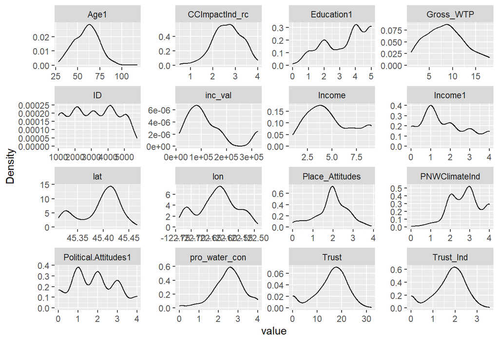

```r
plot_density(watercust)
```

Reduce dataset to variables of interest and convert Likert scale variables to factor Keep attitudinal, demographic and respondent ID to join back to original dataset.

```r
#Change ID to key, it will make joining easier later

watercust <- watercust %>%
  rename(key = ID) %>%
  rename(Educ = Education1) %>%
  rename(Politics = Political.Attitudes1) %>%
  rename(Climate_imp = CCImpactInd_rc) %>%
  rename(Age = Age1)

watercust_dem<- watercust %>%
                select(key,Age,Educ,Politics,inc_val,Climate_imp,
                       pro_water_con,Trust_Ind,Place_Attitudes)

glimpse(watercust_dem)
```

```
## Observations: 381
## Variables: 9
## $ key             <dbl> 1099, 1095, 1175, 1047, 1133, 1003, 1036, 1019, 1167,…
## $ Age             <dbl> 74, NA, 72, 69, 68, 72, 43, 43, 72, 38, NA, NA, 34, 5…
## $ Educ            <dbl> 3, 4, 2, 3, 1, 2, 2, 2, 3, 3, NA, NA, 4, 4, 4, 4, 3, …
## $ Politics        <dbl> 3, 0, 0, 1, 4, 2, NA, 2, 2, 1, NA, NA, 1, 1, 3, 4, 1,…
## $ inc_val         <dbl> 62499.5, 87499.5, 62499.5, 62499.5, 87499.5, 12500.0,…
## $ Climate_imp     <dbl> 1.625, NA, 2.875, 3.125, NA, 2.000, 2.625, 3.250, 2.7…
## $ pro_water_con   <dbl> 1.75, NA, 2.50, 2.50, NA, 1.50, 2.75, 2.75, 2.50, 3.2…
## $ Trust_Ind       <dbl> 1.7777778, 0.3333333, 2.2222222, 1.8888889, 1.6666667…
## $ Place_Attitudes <dbl> 2.0000000, 2.0000000, 1.7777778, 2.0000000, 0.4444444…
```

### Visualize Correlations

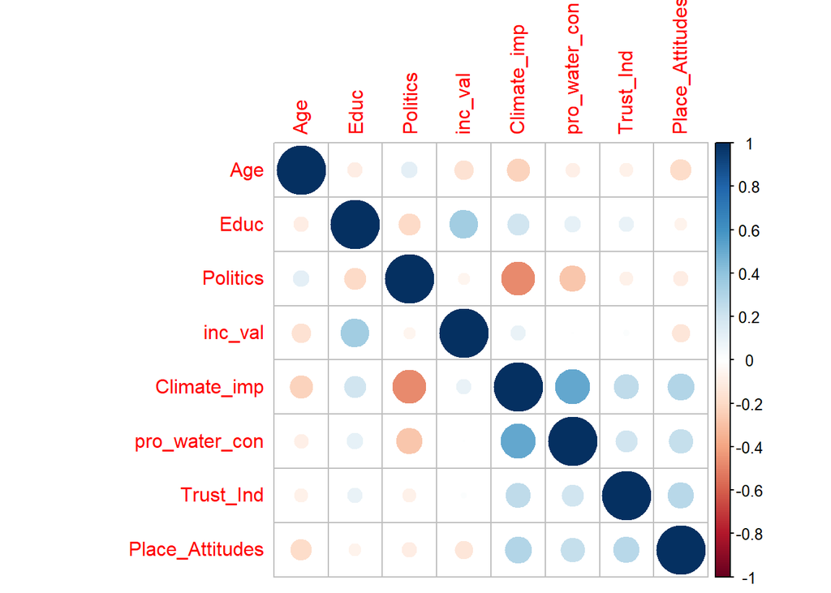

```r
# Make a correlogram to visualize correlations among variables.

watercust_dem_cor<-watercust_dem %>%
  select(-key)

cordta<-watercust_dem_cor
cor1 <- cor(cordta, use="pairwise.complete.obs", method="pearson")

corrplot(cor1)
```

```r
# Compute the p-value of correlations
cor.mtest <- function(mat, ...) {
  mat <- as.matrix(mat)
  n <- ncol(mat)
  p.mat<- matrix(NA, n, n)
  diag(p.mat) <- 0
  for (i in 1:(n - 1)) {
    for (j in (i + 1):n) {
      tmp <- cor.test(mat[, i], mat[, j], ...)
      p.mat[i, j] <- p.mat[j, i] <- tmp$p.value
    }
  }
  colnames(p.mat) <- rownames(p.mat) <- colnames(mat)
  p.mat
}
# matrix of the p-value of the correlation
p.mat <- cor.mtest(watercust_dem_cor)
head(p.mat[, 1:5])
```

```
##                        Age         Educ     Politics      inc_val  Climate_imp
## Age           0.000000e+00 8.748840e-02 3.890890e-02 8.136152e-03 8.071485e-05
## Educ          8.748840e-02 0.000000e+00 1.951600e-04 6.492119e-10 6.267575e-04
## Politics      3.890890e-02 1.951600e-04 0.000000e+00 3.145147e-01 1.011514e-18
## inc_val       8.136152e-03 6.492119e-10 3.145147e-01 0.000000e+00 1.176155e-01
## Climate_imp   8.071485e-05 6.267575e-04 1.011514e-18 1.176155e-01 0.000000e+00
## pro_water_con 1.394588e-01 6.233670e-02 4.609304e-07 9.621151e-01 1.803026e-22
```

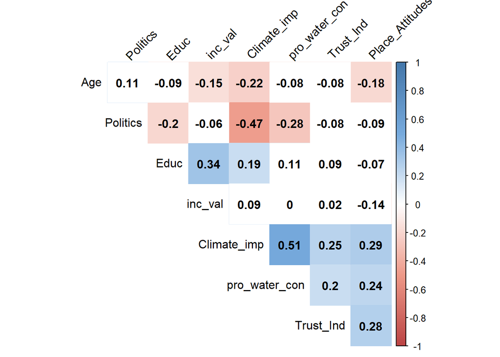

```r
#Customize Correlogram

col <- colorRampPalette(c("#BB4444", "#EE9988", "#FFFFFF", "#77AADD", "#4477AA"))
watercust_cor<-corrplot(cor1, method="color", col=col(200),
         type="upper", order="hclust",
         addCoef.col = "black", # Add coefficient of correlation
         tl.col="black", tl.srt=45, #Text label color and rotation
         # Combine with significance
         p.mat = p.mat, sig.level = 0.01, insig = "blank",
         # hide correlation coefficient on the principal diagonal
         diag=FALSE
)
```

## 3. Hierarchical Cluster Analysis

We want to see what distinct clusters emerge among the attitudinal differences between water customers.

```r
# Subset data for clustering. Make sure 1 dataset has unique key and other does not.So it can be joined back to the spatial dataset later.

watercust_clus_wkey<- watercust_dem %>%
  select(key,Climate_imp,pro_water_con,Trust_Ind,Place_Attitudes)

watercust_clus_nokey <- watercust_dem %>%
  select(Climate_imp,pro_water_con,Trust_Ind,Place_Attitudes)

## Remove Missing Variables

watercust_clus_wkey <- watercust_clus_wkey[complete.cases(watercust_clus_wkey), ]
watercust_clus_nokey <- watercust_clus_nokey[complete.cases(watercust_clus_nokey), ]

## Scale prior to clustering

watercust_clus_nokey_sc <- scale(watercust_clus_nokey)
```

Determining optimal clusters using elbow method.

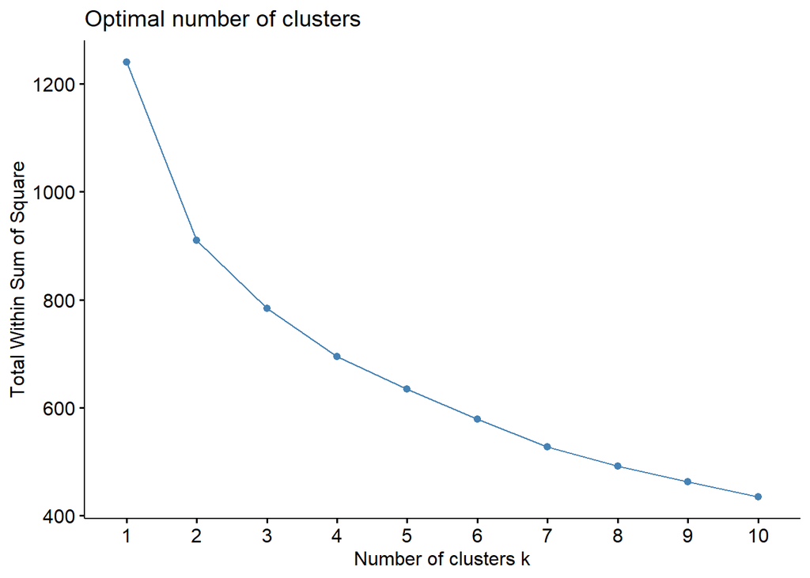

```r
library(cluster)    # clustering algorithms
library(factoextra)

fviz_nbclust(watercust_clus_nokey_sc , FUN = hcut, method = "wss")
```

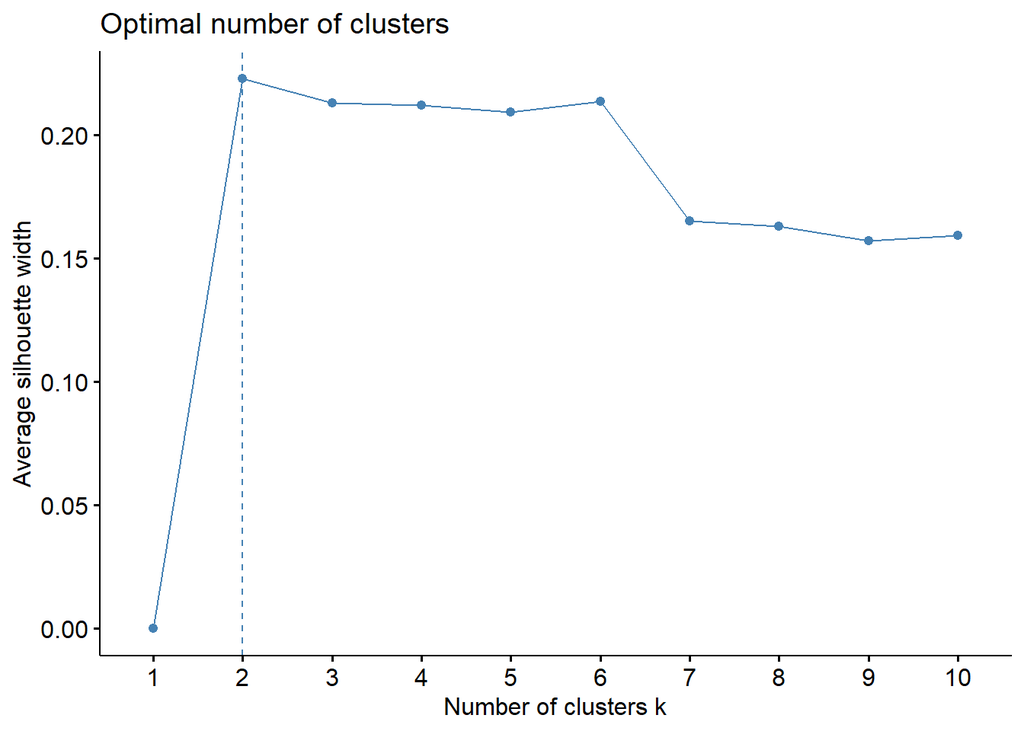

```r
# Method is used for determining the optimal number of clusters. "wss" is
# total within sum of squares

## Average Silhouette Method

fviz_nbclust(watercust_clus_nokey_sc, FUN = hcut, method = "silhouette")
```

Note that both the elbow method and average silhouette width show “2” as the optimal cluster solution. Now we must test optimal number of clusters.

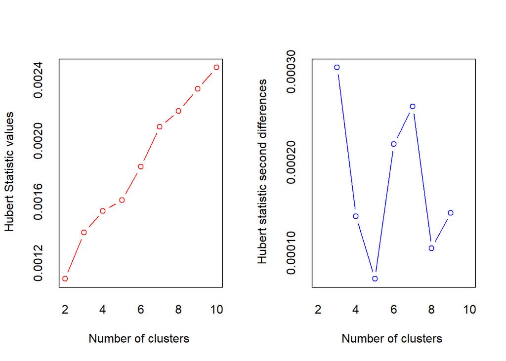

```
## *** : The Hubert index is a graphical method of determining the number of clusters.
##                 In the plot of Hubert index, we seek a significant knee that corresponds to a
##                 significant increase of the value of the measure i.e the significant peak in Hubert
##                 index second differences plot.
##
```

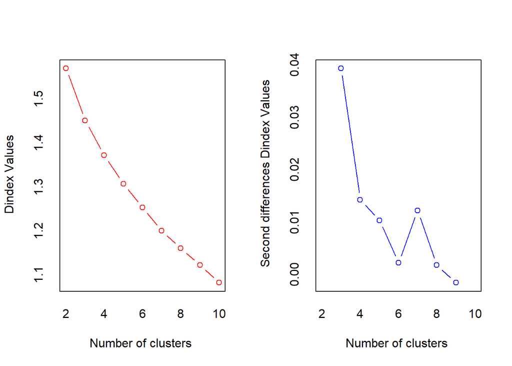

```
## *** : The D index is a graphical method of determining the number of clusters.
##                 In the plot of D index, we seek a significant knee (the significant peak in Dindex
##                 second differences plot) that corresponds to a significant increase of the value of
##                 the measure.
##
## * Among all indices:
## * 8 proposed 2 as the best number of clusters
## * 7 proposed 3 as the best number of clusters
## * 2 proposed 4 as the best number of clusters
## * 1 proposed 5 as the best number of clusters
## * 1 proposed 6 as the best number of clusters
## * 2 proposed 7 as the best number of clusters
## * 2 proposed 10 as the best number of clusters
##
##                    ***** Conclusion *****
##
## * According to the majority rule, the best number of clusters is  2
##
##
```

```r
library("NbClust")
set.seed(42)
res.nbclust = NbClust(watercust_clus_nokey_sc, distance = "euclidean",
                      min.nc = 2, max.nc = 10,
                      method = "ward.D", index = "all")
```

```
## Among all indices:
## ===================
## * 2 proposed  0 as the best number of clusters
## * 1 proposed  1 as the best number of clusters
## * 8 proposed  2 as the best number of clusters
## * 7 proposed  3 as the best number of clusters
## * 2 proposed  4 as the best number of clusters
## * 1 proposed  5 as the best number of clusters
## * 1 proposed  6 as the best number of clusters
## * 2 proposed  7 as the best number of clusters
## * 2 proposed  10 as the best number of clusters
##
## Conclusion
## =========================
## * According to the majority rule, the best number of clusters is  2 .
```

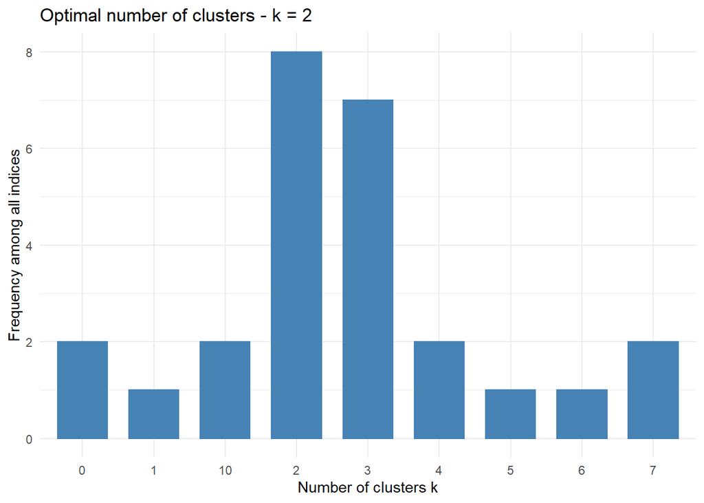

```r
factoextra::fviz_nbclust(res.nbclust)+theme_minimal()
```

Note that package `NbClust` Uses a variety of indices (e.g. Too many to mention - See documentation here NbClust. Optimal number of clusters is 2.

#### Hierarchical Clustering

```r
hc.res <- eclust(watercust_clus_nokey_sc, "hclust", k = 2, hc_metric = "euclidean",
                 hc_method = "ward.D", graph = FALSE)


# Validating the best clustering algorithm. This is incredibly useful.

library(clValid)
watercust_clus_valid = clValid(watercust_clus_nokey_sc, nClust = 2:6,
                               clMethods = c("hierarchical","kmeans","pam"),
                               validation = "internal")
summary(watercust_clus_valid)
```

```
##
## Clustering Methods:
##  hierarchical kmeans pam
##
## Cluster sizes:
##  2 3 4 5 6
##
## Validation Measures:
##                                   2        3        4        5        6
##
## hierarchical Connectivity    6.7536  11.6115  24.9841  59.4004  62.4544
##              Dunn            0.1722   0.1722   0.1237   0.0745   0.0745
##              Silhouette      0.4690   0.2829   0.1640   0.1696   0.0928
## kmeans       Connectivity   73.0341 100.9647 135.2119 164.2484 175.1750
##              Dunn            0.0753   0.0612   0.0510   0.0434   0.0560
##              Silhouette      0.2811   0.2560   0.2133   0.2044   0.1940
## pam          Connectivity   90.2187 144.2794 143.2405 176.1246 181.0567
##              Dunn            0.0618   0.0402   0.0630   0.0377   0.0377
##              Silhouette      0.2683   0.1463   0.1857   0.1811   0.1630
##
## Optimal Scores:
##
##              Score  Method       Clusters
## Connectivity 6.7536 hierarchical 2
## Dunn         0.1722 hierarchical 2
## Silhouette   0.4690 hierarchical 2
```

```r
#Validating Clusters #
library(fpc)
dd <- dist(watercust_clus_nokey_sc, method ="euclidean")

# Statistics for hierarchical clustering
hc_stats <- cluster.stats(dd,  hc.res$cluster)
# (HCLUST) within clusters sum of squares
hc_stats$within.cluster.ss
```

```
## [1] 914.2516
```

```r
hc_stats$clus.avg.silwidths
```

```
##         1         2
## 0.1037415 0.3867614
```

[output not shown]

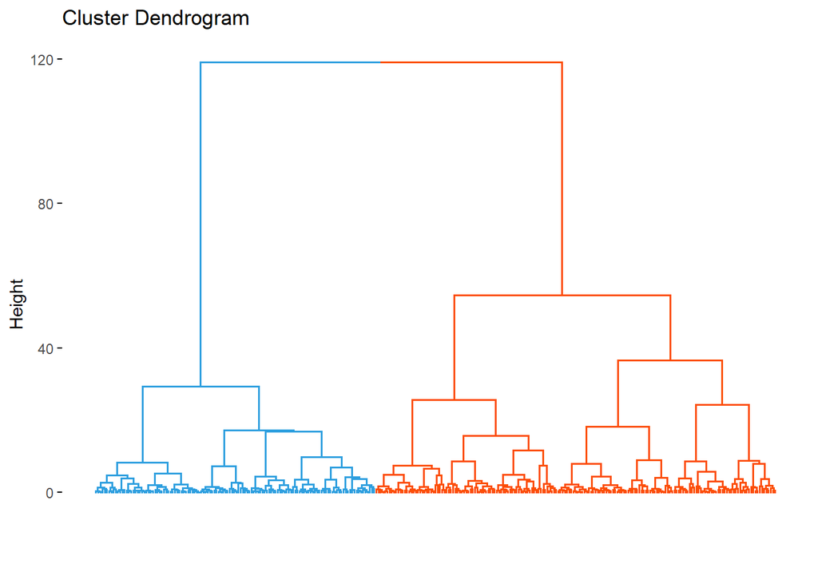

```r
# Visualize Dendrogram

sp = fviz_dend(hc.res, show_labels = FALSE,
               palette = "Set1",main = "Cluster Dendrogram", theme(plot.title = element_text(hjust = 0.5)),cex = 0.75, as.ggplot = TRUE)

sp+ scale_color_manual(values=c("#FC4E07", "#2E9FDF"))
```

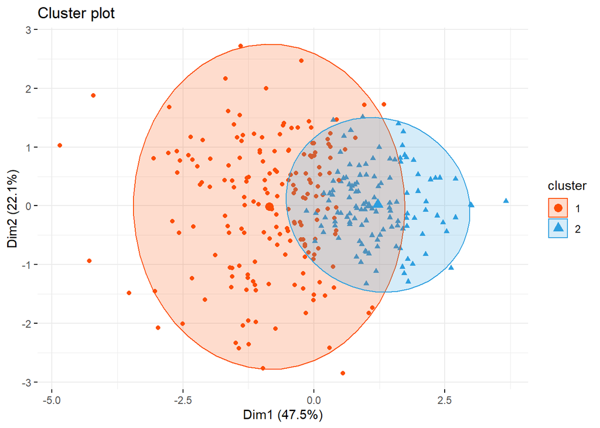

```r
##Plot cluster solution
# Visualize HC clusters
sp2 <- fviz_cluster(hc.res, geom = "point", ellipse.type = "norm",
                    palette = c("#FC4E07", "#2E9FDF"), ggtheme = theme_minimal())
print(sp2)
```

```r
# Cut tree into 2 groups and attach to original data

sub_grp <- cutree(hc.res, k = 2)
clusters <- sub_grp
clusters<-as.data.frame(clusters)
```

Join clusters back to original data. Select only relevant variables. Rename variables with unintelligible names. Then save out the data for future analyses.

```r
watercust_clusters<- watercust_clus_wkey %>%
  bind_cols(clusters) %>%
  left_join(watercust,watercust_clusters, by="key") %>%
  select(key,Age,Educ,Politics,inc_val,Climate_imp.y,pro_water_con.y,Trust_Ind.y,Place_Attitudes.y,clusters,lon,lat) %>%
  rename(Respondent = key)
names(watercust_clusters)<- gsub(".y", "", names(watercust_clusters))

# Save out the data

save(watercust_clusters, file = "watercust_clusters.RData")
```

## 4. Validate Clusters with MANOVA

We are looking to see if there is a significant difference in means between the two groups. Hence the need for MANOVA.

```r
library(MASS)
## Subset cluster output

man_dta<-watercust_clusters %>%
  dplyr::select(clusters,Climate_imp,pro_water_con,Trust_Ind,Place_Attitudes)

# Perform MANOVA
set.seed(42)

man_dta$clusters = as.factor(man_dta$clusters)
Y = as.matrix(cbind(man_dta$Climate_imp, man_dta$pro_water_con, man_dta$Trust_Ind,man_dta$Place_Attitudes))
c = as.vector(man_dta$clusters)


m = manova(Y~c)
summary(m , test = "Pillai")
```

```
##            Df  Pillai approx F num Df den Df    Pr(>F)
## c           1 0.55881   96.893      4    306 < 2.2e-16 ***
## Residuals 309
## ---
## Signif. codes:  0 '***' 0.001 '**' 0.01 '*' 0.05 '.' 0.1 ' ' 1
```

```r
summary(m , test = "Wilks")
```

```
##            Df   Wilks approx F num Df den Df    Pr(>F)
## c           1 0.44119   96.893      4    306 < 2.2e-16 ***
## Residuals 309
## ---
## Signif. codes:  0 '***' 0.001 '**' 0.01 '*' 0.05 '.' 0.1 ' ' 1
```

```r
summary(m , test = "Hotelling-Lawley")
```

```
##            Df Hotelling-Lawley approx F num Df den Df    Pr(>F)
## c           1           1.2666   96.893      4    306 < 2.2e-16 ***
## Residuals 309
## ---
## Signif. codes:  0 '***' 0.001 '**' 0.01 '*' 0.05 '.' 0.1 ' ' 1
```

```r
summary(m , test = "Roy")
```

```
##            Df    Roy approx F num Df den Df    Pr(>F)
## c           1 1.2666   96.893      4    306 < 2.2e-16 ***
## Residuals 309
## ---
## Signif. codes:  0 '***' 0.001 '**' 0.01 '*' 0.05 '.' 0.1 ' ' 1
```

We can infer from the tests that the clusters are indeed statistically different from one another.

## 5. Interpret Clusters

Now it’s time to make some summary tables to interpret the clusters. To do this we will look at summary statistics, along with proportions of respondents belonging to specific segments of the repective attitudinal scales (e.g. Low Trust vs. High Trust).

```r
summary(watercust_clusters)
```

```
##    Respondent        Age              Educ         Politics
##  Min.   :1003   Min.   : 28.00   Min.   :0.00   Min.   :0.000
##  1st Qu.:2070   1st Qu.: 49.00   1st Qu.:2.00   1st Qu.:1.000
##  Median :3139   Median : 60.00   Median :4.00   Median :2.000
##  Mean   :3160   Mean   : 59.34   Mean   :3.48   Mean   :1.797
##  3rd Qu.:4188   3rd Qu.: 68.50   3rd Qu.:5.00   3rd Qu.:3.000
##  Max.   :5755   Max.   :106.00   Max.   :5.00   Max.   :4.000
##                 NA's   :12       NA's   :11     NA's   :6
##     inc_val        Climate_imp    pro_water_con    Trust_Ind
##  Min.   : 12500   Min.   :0.500   Min.   :0.00   Min.   :0.000
##  1st Qu.: 62500   1st Qu.:2.250   1st Qu.:2.00   1st Qu.:1.333
##  Median : 87500   Median :2.625   Median :2.50   Median :1.889
##  Mean   :123310   Mean   :2.649   Mean   :2.51   Mean   :1.753
##  3rd Qu.:162500   3rd Qu.:3.125   3rd Qu.:3.00   3rd Qu.:2.222
##  Max.   :323559   Max.   :4.000   Max.   :4.00   Max.   :3.556
##  NA's   :37
##  Place_Attitudes    clusters          lon              lat
##  Min.   :0.000   Min.   :1.000   Min.   :-122.7   Min.   :45.31
##  1st Qu.:1.611   1st Qu.:1.000   1st Qu.:-122.7   1st Qu.:45.37
##  Median :2.000   Median :1.000   Median :-122.6   Median :45.40
##  Mean   :1.959   Mean   :1.412   Mean   :-122.6   Mean   :45.39
##  3rd Qu.:2.444   3rd Qu.:2.000   3rd Qu.:-122.6   3rd Qu.:45.42
##  Max.   :3.889   Max.   :2.000   Max.   :-122.5   Max.   :45.47
##
```

```r
# Consider separating into two datasets then combining in the end.

watercust_clust1 <- watercust_clusters %>%
  filter(clusters ==1)

watercust_clust2 <- watercust_clusters %>%
  filter(clusters ==2)
```

##### Begin by looking at Cluster 1

```r
# Age
summary(watercust_clust1$Age)
```

```
##    Min. 1st Qu.  Median    Mean 3rd Qu.    Max.    NA's
##   29.00   53.00   62.00   61.55   70.25  106.00      11
```

```r
#Income
summary(watercust_clust1$inc_val)
```

```
##    Min. 1st Qu.  Median    Mean 3rd Qu.    Max.    NA's
##   12500   62500   87500  121151  162500  323559      29
```

```r
#Education

clust1_ed<-watercust_clust1%>% filter(!is.na(Educ))
clust1_ed <- clust1_ed%>% group_by(Educ) %>% summarise(n = n()) %>% ungroup() %>%
  mutate(total = sum(n), share = n/total) %>%
  filter(Educ >= 4)

bachelor_or_higher1<-sum(clust1_ed$share)

summary(clust1_ed)
```

```
##       Educ            n             total         share
##  Min.   :4.00   Min.   :41.00   Min.   :173   Min.   :0.2370
##  1st Qu.:4.25   1st Qu.:43.75   1st Qu.:173   1st Qu.:0.2529
##  Median :4.50   Median :46.50   Median :173   Median :0.2688
##  Mean   :4.50   Mean   :46.50   Mean   :173   Mean   :0.2688
##  3rd Qu.:4.75   3rd Qu.:49.25   3rd Qu.:173   3rd Qu.:0.2847
##  Max.   :5.00   Max.   :52.00   Max.   :173   Max.   :0.3006
```

```r
print(bachelor_or_higher1)
```

```
## [1] 0.5375723
```

```r
# Politics

watercust_clust1<-watercust_clust1 %>% filter(!is.na(Politics))

#ELSE <- TRUE
politics <- watercust_clust1%>% mutate(PoliticsSummary =
                                         case_when( Politics >= 0 &
                                                      Politics < 2 ~ "Liberal",
                                                    Politics >= 2 &
                                                      Politics < 3 ~ "Neutral",
                                                    Politics >= 4 ~ "Conservative")) %>%
  dplyr::select(Politics, PoliticsSummary)
polp1 <- politics %>% group_by(PoliticsSummary) %>% summarise(n = n()) %>% ungroup() %>%
  mutate(total = sum(n), share = n/total)
print(polp1)
```

```
## # A tibble: 4 x 4
##   PoliticsSummary     n total share
##   <chr>           <int> <int> <dbl>
## 1 Conservative       19   178 0.107
## 2 Liberal            49   178 0.275
## 3 Neutral            62   178 0.348
## 4 <NA>               48   178 0.270
```

```r
# Climate Change Impact Beliefs

watercust_clust1<-watercust_clust1 %>% filter(!is.na(Climate_imp))

#ELSE <- TRUE
climate1<- watercust_clust1 %>% mutate(pnwSummary1 =
                                         case_when( Climate_imp >= 0 &
                                                      Climate_imp < 2 ~ "Low",
                                                    Climate_imp >= 2 &
                                                      Climate_imp< 3 ~ "Medium",
                                                    Climate_imp >= 3 ~ "High")) %>%
  dplyr::select(Climate_imp, pnwSummary1)
pnwp1 <- climate1  %>% dplyr::group_by(pnwSummary1) %>% summarise(n = n()) %>% ungroup() %>%
  mutate(total = sum(n), share = n/total)

print(pnwp1)
```

```
## # A tibble: 3 x 4
##   pnwSummary1     n total share
##   <chr>       <int> <int> <dbl>
## 1 High           20   178 0.112
## 2 Low            30   178 0.169
## 3 Medium        128   178 0.719
```

```r
# Pro Water Conservation


watercust_clust1<-watercust_clust1 %>% filter(!is.na(pro_water_con))

clust1_prowat<- watercust_clust1 %>% mutate(pro_water_conSummary1 =
                                              case_when( pro_water_con >= 0 &
                                                           pro_water_con < 2 ~ "Low",
                                                         pro_water_con >= 2 &
                                                           pro_water_con < 3 ~ "Medium",
                                                         pro_water_con >= 3 ~ "High")) %>%
  dplyr::select(pro_water_con, pro_water_conSummary1)
prowatp1 <- clust1_prowat  %>% dplyr::group_by(pro_water_conSummary1) %>% summarise(n = n()) %>% ungroup() %>%
  mutate(total = sum(n), share = n/total)

print(prowatp1)
```

```
## # A tibble: 3 x 4
##   pro_water_conSummary1     n total share
##   <chr>                 <int> <int> <dbl>
## 1 High                     30   178 0.169
## 2 Low                      52   178 0.292
## 3 Medium                   96   178 0.539
```

```r
# Trust

watercust_clust1<-watercust_clust1 %>% filter(!is.na(Trust_Ind))

#ELSE <- TRUE
clust1_trust<- watercust_clust1 %>% mutate(Trust_IndexSummary1 =
                                             case_when( Trust_Ind >= 0 &
                                                          Trust_Ind < 2 ~ "Low",
                                                        Trust_Ind >= 2 &
                                                          Trust_Ind < 3 ~ "Medium",
                                                        Trust_Ind >= 3 ~ "High")) %>%
  dplyr::select(Trust_Ind, Trust_IndexSummary1)
trustp1 <- clust1_trust  %>% dplyr::group_by(Trust_IndexSummary1) %>% summarise(n = n()) %>% ungroup() %>%
  mutate(total = sum(n), share = n/total)

print(trustp1)
```

```
## # A tibble: 3 x 4
##   Trust_IndexSummary1     n total  share
##   <chr>               <int> <int>  <dbl>
## 1 High                    4   178 0.0225
## 2 Low                   128   178 0.719
## 3 Medium                 46   178 0.258
```

```r
# Place Attitudes

watercust_clust1<-watercust_clust1 %>% filter(!is.na(Place_Attitudes))

#ELSE <- TRUE
pl_attitudes <- watercust_clust1 %>% mutate(AttitudeSummary1 =
                                              case_when( Place_Attitudes >= 0 &
                                                           Place_Attitudes < 2 ~ "Low",
                                                         Place_Attitudes >= 2 &
                                                           Place_Attitudes < 3 ~ "Medium",
                                                         Place_Attitudes >= 4 ~ "High")) %>%
  dplyr::select(Place_Attitudes, AttitudeSummary1)
attp1 <- pl_attitudes %>% group_by(AttitudeSummary1) %>% summarise(n = n()) %>% ungroup() %>%
  mutate(total = sum(n), share = n/total)

print(attp1)
```

```
## # A tibble: 3 x 4
##   AttitudeSummary1     n total  share
##   <chr>            <int> <int>  <dbl>
## 1 Low                100   178 0.562
## 2 Medium              74   178 0.416
## 3 <NA>                 4   178 0.0225
```